# Exploring Toronto Bike Share Ridership

### Haiyue Yang, January 2020

## Introduction

In recent years, Bike Sharing has become increasingly popular aroung the world. It is a both convenient and ecological way to explore the city. Thus, I was attracted be the Bike Share Ridership in Toronto and decided to explore the ridership using Python.

My exploration focused on the difference of riderships between casual users and members and the inflence of weather on the ridership.

By understanding these traits of the bikeshare data, can we know how to develop the bikeshare program in the future.

## Data Wrangling

### 1. About the Data

My research is mainly based on the datasets of the bikeshare ridership in 2017 and the second half of 2016, provided on Open Data (https://open.toronto.ca/dataset/bike-share-toronto-ridership-data), combined with weather information on [Historical Climate Data website](https://climate.weather.gc.ca/) and station information on https://open.toronto.ca/dataset/bike-share-toronto/.

- **ridership_data.csv**
  - `trip_id`: the unique identifier for each trip
  - `trip_start_time`: the time when the trip started
  - `trip_stop_time`: the time when the trip stopped
  - `trip_duration_seconds`: the duration of trip measured in seconds
  - `from_station_name`: the name of the station where the trip started
  - `to_station_name`: the name of the station where the trip ended
  - `user_type`: the user has the membership or is a casual user
  - `from_station_id`: the unique identifier of the station where the trip started
  - `to_station_id`: the unique identifier of the station where the trip ended
- **station_data.csv**
  - `station_id`: the unique identifier of the station
  - `name`: the name of the station
  - `lat`: the latitude of the station
  - `lon`: the longitude of the station
- **bikeshare_data.csv**
  - `user_type`: the user has the membership or is a casual user
  - `trip_duration_seconds`: the duration of trip measured in seconds
  - `distance`: the distance in straight line of the trip measured in meters
  - `date`: the date of the trip
- **weather_data.csv**
  - `mean_temp`: the mean temperature of the day
  - `total_precip`: the total precipitation of the day
  - `date`: the date of the day
  - `duration`: the mean duration of trips in the day measured in seconds
  - `distance`: the mean distance of trips in they day measure in meters

### 2. Data Cleaning and Combination

- **Bikeshare Ridership Data**

The bikeshare Ridership Data contains 6 dataframes separated by quarter. The data were retrived from Open Data (https://open.toronto.ca/dataset/bike-share-toronto-ridership-data).

During my exploration, I noticed that the data in each dataframe is not standarized. Therefore, I standarized the data fisrt.

**Firstly**, I dropped out rows with null values, made sure all data in `trip_start_time` and `trip_stop_time` in Q3 of 2016 are of type datetime and added a column representing the quarter of the data.

**Secondly**, I noticed that there were different formats in `trip_start_time` and `trip_stop_time` in Q4 of 2016. For example, look at the first and last 5 rows of the dataframe: the `trip_start_time` and `trip_stop_time` in the head is of type datetime, but the month and the day were placed in the wrong order; the `trip_start_time` and `trip_stop_time` in the tail is of type string and in the format '%d/%m/%Y %H:%M'.

|  | trip_id | trip_start_time | trip_stop_time | trip_duration_seconds | from_station_name | to_station_name | user_type |
| --- | --- | --- | --- | --- | --- | --- | --- |
| 0 | 462305 | 2016-01-10 00:00:00 | 2016-01-10 00:07:00 | 394 | Queens Quay W / Dan Leckie Way | Fort York Blvd / Garrison Rd | Casual |
| 1 | 462306 | 2016-01-10 00:00:00 | 2016-01-10 00:09:00 | 533 | Sherbourne St / Wellesley St | Edward St / Yonge St | Member |
| 2 | 462307 | 2016-01-10 00:00:00 | 2016-01-10 00:07:00 | 383 | Queens Quay W / Dan Leckie Way | Fort York Blvd / Garrison Rd | Casual |
| 3 | 462308 | 2016-01-10 00:01:00 | 2016-01-10 00:27:00 | 1557 | Cherry St / Distillery Ln | Fort York Blvd / Capreol Crt | Casual |
| 4 | 462309 | 2016-01-10 00:01:00 | 2016-01-10 00:27:00 | 1547 | Cherry St / Distillery Ln | Fort York Blvd / Capreol Crt | Casual |
| ... | ... | ... | ... | ... | ... | ... | ... |
| 217564 | 712377 | 31/12/2016 23:26 | 31/12/2016 23:39 | 824 | Union Station | Gould St / Mutual St | Member |
| 217565 | 712378 | 31/12/2016 23:26 | 31/12/2016 23:34 | 478 | Bay St / College St (East Side) | Beverly St / Dundas St W | Member |
| 217566 | 712379 | 31/12/2016 23:33 | 31/12/2016 23:38 | 271 | Temperance St / Yonge St | Victoria St / Gould St (Ryerson University) | Member |
| 217567 | 712380 | 31/12/2016 23:37 | 31/12/2016 23:58 | 1253 | Christie St / Benson Ave (Wychwood Barns) | Wellesley St E / Yonge St Green P | Member |
| 217568 | 712381 | 31/12/2016 23:40 | 31/12/2016 23:48 | 478 | Ted Rogers Way / Bloor St E | St George St / Bloor St W | Member |

217569 rows × 7 columns

Thus, I standarized these two columns into datetime.datetime in the format '%Y-%m-%d %H:%M:%S', dropped out rows with null values, and added a column representing the quarter of the data.

**After that**, I combined the two dataframe in year 2016 and added a column representing the year.

Further more, I noticed that the data in year 2016 does not contain `from_station_id` and `to_statoin_id`, so I added this two columns with NaN value for use in the future.

|  | trip_id | trip_start_time | trip_stop_time | trip_duration_seconds | from_station_name | to_station_name | user_type | quarter | year | from_station_id | to_station_id |
| --- | --- | --- | --- | --- | --- | --- | --- | --- | --- | --- | --- |
| 0 | 53279 | 2016-07-09 01:03:00 | 2016-07-09 01:15:00 | 714 | Dundas St E / Regent Park Blvd | Danforth Ave / Ellerbeck St | Member | Q3 | 2016 | NaN | NaN |
| 1 | 53394 | 2016-07-09 02:15:00 | 2016-07-09 02:22:00 | 417 | Riverdale Park North (Broadview Ave) | Dundas St E / Regent Park Blvd | Member | Q3 | 2016 | NaN | NaN |
| 2 | 58314 | 2016-07-10 17:04:00 | 2016-07-10 17:36:00 | 1904 | Dundas St E / Regent Park Blvd | Queen St W / Close Ave | Member | Q3 | 2016 | NaN | NaN |
| 3 | 60784 | 2016-07-11 01:45:00 | 2016-07-11 01:58:00 | 784 | Union Station | Dundas St E / Regent Park Blvd | Member | Q3 | 2016 | NaN | NaN |
| 4 | 93164 | 2016-07-18 13:35:00 | 2016-07-18 13:42:00 | 443 | Front St W / Blue Jays Way | Front St / Yonge St (Hockey Hall of Fame) | Member | Q3 | 2016 | NaN | NaN |

**Next**, I continued to clean up the data in 2017. Similar to the data in 2016, I dropped out rows containing null values, changed different formats in `trip_start_time` and `trip_stop_time` into datetime.datetime in the format '%Y-%m-%d %H:%M:%S' and added a column representing the quarter for each dataframe.

**Then**, I merged these four dataframes and added a column representing the year.

Also, I noticed that in Q3 and Q4 of year 2017, the columns of `from_station_id` and `to_statoin_id` is still missing, but I leaved the value of them NaN for future adjustment.

|  | trip_id | trip_start_time | trip_stop_time | trip_duration_seconds | from_station_id | from_station_name | to_station_id | to_station_name | user_type | quarter | year |
| --- | --- | --- | --- | --- | --- | --- | --- | --- | --- | --- | --- |
| 0 | 712382 | 2017-01-01 00:00:00 | 2017-01-01 00:03:00 | 223 | 7051.0 | Wellesley St E / Yonge St Green P | 7089.0 | Church St / Wood St | Member | Q1 | 2017 |
| 1 | 712383 | 2017-01-01 00:00:00 | 2017-01-01 00:05:00 | 279 | 7143.0 | Kendal Ave / Bernard Ave | 7154.0 | Bathurst Subway Station | Member | Q1 | 2017 |
| 2 | 712384 | 2017-01-01 00:05:00 | 2017-01-01 00:29:00 | 1394 | 7113.0 | Parliament St / Aberdeen Ave | 7199.0 | College St W / Markham St | Member | Q1 | 2017 |
| 3 | 712385 | 2017-01-01 00:07:00 | 2017-01-01 00:21:00 | 826 | 7077.0 | College Park South | 7010.0 | King St W / Spadina Ave | Member | Q1 | 2017 |
| 4 | 712386 | 2017-01-01 00:08:00 | 2017-01-01 00:12:00 | 279 | 7079.0 | McGill St / Church St | 7047.0 | University Ave / Gerrard St W | Member | Q1 | 2017 |

**After that**, we got the combined data from year 2017 and year 2016 (partial). We concatenated them and get a dataframe named `df` containing the bikeshare ridership data in whole.

Also, considering the convenience of future use, I again ensured that all data in`trip_start_time` and `trip_stop_time` are of type datetime and in the format '%Y-%m/%d %H:%M:%S', and all data in `from_station_id` and `to_station_id` are saved as float.

|  | trip_id | trip_start_time | trip_stop_time | trip_duration_seconds | from_station_name | to_station_name | user_type | quarter | year | from_station_id | to_station_id |
| --- | --- | --- | --- | --- | --- | --- | --- | --- | --- | --- | --- |
| 0 | 53279 | 2016-07-09 01:03:00 | 2016-07-09 01:15:00 | 714 | Dundas St E / Regent Park Blvd | Danforth Ave / Ellerbeck St | Member | Q3 | 2016 | NaN | NaN |
| 1 | 53394 | 2016-07-09 02:15:00 | 2016-07-09 02:22:00 | 417 | Riverdale Park North (Broadview Ave) | Dundas St E / Regent Park Blvd | Member | Q3 | 2016 | NaN | NaN |
| 2 | 58314 | 2016-07-10 17:04:00 | 2016-07-10 17:36:00 | 1904 | Dundas St E / Regent Park Blvd | Queen St W / Close Ave | Member | Q3 | 2016 | NaN | NaN |
| 3 | 60784 | 2016-07-11 01:45:00 | 2016-07-11 01:58:00 | 784 | Union Station | Dundas St E / Regent Park Blvd | Member | Q3 | 2016 | NaN | NaN |
| 4 | 93164 | 2016-07-18 13:35:00 | 2016-07-18 13:42:00 | 443 | Front St W / Blue Jays Way | Front St / Yonge St (Hockey Hall of Fame) | Member | Q3 | 2016 | NaN | NaN |
| ... | ... | ... | ... | ... | ... | ... | ... | ... | ... | ... | ... |
| 1492363 | 2383642 | 2017-12-31 23:46:27 | 2017-12-31 23:46:53 | 26 | Bloor St / Brunswick Ave | Bloor St / Brunswick Ave | Casual | Q4 | 2017 | NaN | NaN |
| 1492364 | 2383643 | 2017-12-31 23:47:13 | 2018-01-01 00:11:40 | 1467 | Bloor St / Brunswick Ave | HTO Park (Queens Quay W) | Casual | Q4 | 2017 | NaN | NaN |
| 1492365 | 2383644 | 2017-12-31 23:47:40 | 2017-12-31 23:57:49 | 609 | Kendal Ave / Spadina Rd | Augusta Ave / Denison Sq | Member | Q4 | 2017 | NaN | NaN |
| 1492366 | 2383645 | 2017-12-31 23:49:08 | 2017-12-31 23:49:34 | 26 | Phoebe St / Spadina Ave | Phoebe St / Spadina Ave | Member | Q4 | 2017 | NaN | NaN |
| 1492367 | 2383646 | 2017-12-31 23:49:41 | 2017-12-31 23:57:41 | 480 | Phoebe St / Spadina Ave | Simcoe St / Queen St W | Member | Q4 | 2017 | NaN | NaN |

2077890 rows × 11 columns

**Finally**, I save this dataframe `df` as a csv file named `ridership_data.csv` for reference.

- **station data**

**First**, I imported the station data from [Open Data](https://open.toronto.ca/dataset/bike-share-toronto/) in order to find the latitude and longitude of each station.

These stations are not matched with station IDs.

```
WARN: Victoria St / Gould St (Ryerson University) station could not be matched to an existing station
WARN: Bloor St / Brunswick Ave station could not be matched to an existing station
WARN: Bay St / Bloor St W station could not be matched to an existing station
WARN: Bremner Blvd / Spadina Ave station could not be matched to an existing station
WARN: Dockside Dr / Queens Quay E (Sugar Beach) station could not be matched to an existing station
WARN: Temperance St / Yonge St station could not be matched to an existing station
WARN: Ontario Place Blvd / Remembrance Dr station could not be matched to an existing station
WARN: Landsdowne Subway Green P station could not be matched to an existing station
WARN: Bathurst St / Queens Quay W station could not be matched to an existing station
WARN: Bloor GO / UP Station/ Rail Path station could not be matched to an existing station
WARN: Stephenson Ave / Main St station could not be matched to an existing station
WARN: Woodbine Subway Green P (Cedarvale Ave) station could not be matched to an existing station
WARN: Margueretta St / College St W station could not be matched to an existing station
WARN: Base Station station could not be matched to an existing station
WARN: Michael Sweet Ave / St. Patrick St station could not be matched to an existing station
WARN: Margueretta St / College St station could not be matched to an existing station
WARN: Lansdowne Subway Green P station could not be matched to an existing station
WARN: Roxton Rd / College St station could not be matched to an existing station
WARN: Lake Shore Blvd W / Ontario Dr(Ontario Place) station could not be matched to an existing station
WARN: Fringe Next Stage - 7219 station could not be matched to an existing station
```

**Then**, we got a dataframe for the `name`, `station_id`, `lat`, and `lon` for each station and saved it as a csv file named `station_data`.

|  | station_id | name | lat | lon |
| --- | --- | --- | --- | --- |
| 0 | 7051.0 | Wellesley St E / Yonge St Green P | 43.665060 | -79.383570 |
| 2 | 7051.0 | Wellesley St E / Yonge St (Green P) | 43.665060 | -79.383570 |
| 3 | 7143.0 | Kendal Ave / Bernard Ave | 43.671513 | -79.408317 |
| 5 | 7113.0 | Parliament St / Aberdeen Ave | 43.665278 | -79.368333 |
| 7 | 7077.0 | College Park South | 43.659777 | -79.382767 |

**Next**, I merged the bikeshare ridership information with the station infomation and calculated the `distance` (trip distance) from the `lat` (latitude) and `lon` (longitude) of the stations.

Since the stations are all in Toronto, when calculating the distance, we ignored the angle and simplifed each degree of longitude or latitude to 111 km, and the results are in meters.

**After that**, I sorted out the `date` of each trip, and selected out the columns `user_type`, `trip_duration_seconds`, `distance`, and `date` for future use.

**Then**, we started to clean up the data.

I drew the boxplots for `distance` and `trip_duration_seconds` and used the `describe()` function on these two colums to see a simple profile of the data.

I discovered that there were obvious outliers in these two datasets.

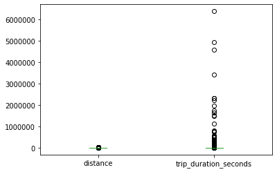

|  | distance | trip_duration_seconds |
| --- | --- | --- |
| count | 2.088646e+06 | 2.088646e+06 |
| mean | 2.058137e+03 | 9.852265e+02 |
| std | 1.442705e+03 | 8.276238e+03 |
| min | 0.000000e+00 | 1.000000e+00 |
| 25% | 1.108542e+03 | 4.180000e+02 |
| 50% | 1.763431e+03 | 6.550000e+02 |
| 75% | 2.697429e+03 | 1.013000e+03 |
| max | 2.058279e+04 | 6.382030e+06 |

A common definition for outliers are the values 1.5*IQR larger than the 75% quantile or 1.5*IQR less than the 25% quantile.

To avoid the interference of extreme values in analysis, I removed all the outliers of `distance` and `trip_duration_seconds` under this definition.

Also, the trips less than 1 minute is considered to be invalid, so I removed the rows with `trip_duration_seconds` less than 60.

|  | user_type | trip_duration_seconds | distance | date |
| --- | --- | --- | --- | --- |
| 311884 | Member | 60 | 304.438682 | 2017-12-04 |
| 1321925 | Casual | 60 | 545.910161 | 2017-06-24 |
| 1321926 | Casual | 60 | 545.910161 | 2017-06-24 |
| 1677842 | Member | 60 | 293.349145 | 2017-10-13 |
| 92489 | Member | 60 | 284.000422 | 2017-04-05 |
| ... | ... | ... | ... | ... |
| 40178 | Casual | 1905 | 2917.085231 | 2017-08-10 |
| 1334895 | Member | 1905 | 2459.398093 | 2017-08-18 |
| 1232396 | Casual | 1905 | 397.869107 | 2017-09-27 |
| 1396718 | Casual | 1905 | 4330.255093 | 2017-04-10 |
| 67846 | Casual | 1905 | 3431.510926 | 2017-07-09 |

1841201 rows × 4 columns

**Finally**, I got the dataframe `data` used for my research and saved it as a csv file named `bikeshare_data.csv` for reference.

- **weather data**

**Firstly**, I scraped the wheather data from the Government of Canada [Historical Climate Data website](https://climate.weather.gc.ca/climate_data/daily_data_e.html?StationID=51459&timeframe=2&StartYear=1840&EndYear=2019&Day=22&Year=2017&Month=1#).

According to the terms of use of the data:

> - We can reproduce the materials on [Historical Climate Data website](https://climate.weather.gc.ca/) in whole or in part for non-commercial purposes, and in any format, without charge or further permission, provided we do the following:
>   - ensuring the accuracy of the material reproduced
>   - indicate both the complete title of the materials reproduced, as well as the author (where available)
>   - indicate that the reproduction is a copy of the a version avaible at [URL where original document is available]
> - Unless otherwise specified, we may not reproduce materials on [Historical Climate Data website](https://climate.weather.gc.ca/), in whole or in part, for the purposes of commercial redistribution without prior written permission from the copyright administrator.

There are 18 dataframes from the website for different months and I had to scraped them separately. I wrote a function `month` which takes the url and the number of days in the month, and returns the dataframe for each month to scrap.

For convenience of later use, I only scraped the columns `Mean Temp Definition °C` and `Total Precip Definitinomm` for each month.

After that, I concatenated the 18 dataframes and got the dataframe `weather`.

Also, for later use, I added a column representing the `date`.

|  | Mean Temp Definition°C | Total Precip Definitionmm | date |
| --- | --- | --- | --- |
| 0 | 18.3 | 5.6 | 2016-07-01 |
| 1 | 19.4 | 0.0 | 2016-07-02 |
| 2 | 21.0 | 0.0 | 2016-07-03 |
| 3 | 21.8 | 0.0 | 2016-07-04 |
| 4 | 26.1 | 0.0 | 2016-07-05 |

**Secondly**, I grouped the ridership data by `date`, calculated the mean `trip_duration_seconds` and `distance`, and got a new dataframe giving the mean `trip_duration_secodns` and `distance` of each`date`.

|  | date | trip_duration_seconds | distance |
| --- | --- | --- | --- |
| 0 | 2016-07-01 | 755.201842 | 1813.031033 |
| 1 | 2016-07-02 | 867.896169 | 1899.371816 |
| 2 | 2016-07-03 | 862.735355 | 1879.030543 |
| 3 | 2016-07-04 | 723.247626 | 1883.836123 |
| 4 | 2016-07-05 | 714.957033 | 1905.608854 |

**Then**, I merged the new dataframe with the weather information, removed some unprecise data such as EE and MM, and got the dataframe for analysis named `weather_data`.

The `weather_data` dataframe contains the `Mean Temp Definition °C`(mean temperature measured in °C), the `Total Precip Definitionmm` (total precipitation measure in mm), `date`, the mean `trip_duration_seconds`, and the mean `distance` travelled of each day.

|  | Mean Temp Definition°C | Total Precip Definitionmm | date | trip_duration_seconds | distance |
| --- | --- | --- | --- | --- | --- |
| 0 | 18.3 | 5.6 | 2016-07-01 | 755.201842 | 1813.031033 |
| 1 | 19.4 | 0.0 | 2016-07-02 | 867.896169 | 1899.371816 |
| 2 | 21.0 | 0.0 | 2016-07-03 | 862.735355 | 1879.030543 |
| 3 | 21.8 | 0.0 | 2016-07-04 | 723.247626 | 1883.836123 |
| 4 | 26.1 | 0.0 | 2016-07-05 | 714.957033 | 1905.608854 |

**Also**, in order to avoid the influence of extreme values, I removed outliers of the `Mean Temp Definition °C`(mean temperature measured in °C), the `Total Precip Definitionmm`. The ourliers are still defined as the values 1.5*IQR larger than the 75% quantile or 1.5*IQR less than the 25% quantile.

Also, considering the convenience of use, I rename some of the columns:

- `Mean Temp Definition°C` is named `mean_temp`
- `Total Precip Definitionmm` is named `total_precip`
- `trip_duration_seconds` is named `duration`

Now, the dataframe `weather_data` is ready for analysis.

|  | mean_temp | total_precip | date | duration | distance |
| --- | --- | --- | --- | --- | --- |
| 439 | -18.6 | 0.0 | 2017-12-31 | 528.588068 | 1503.407902 |
| 380 | 15.6 | 0.0 | 2017-10-22 | 760.956976 | 2006.176339 |
| 379 | 15.4 | 0.0 | 2017-10-21 | 760.617095 | 2010.001245 |
| 212 | 6.5 | 0.0 | 2017-04-17 | 677.873105 | 1979.282584 |
| 213 | 4.7 | 0.0 | 2017-04-18 | 635.482430 | 1965.247389 |
| ... | ... | ... | ... | ... | ... |
| 220 | 17.2 | 5.4 | 2017-04-27 | 673.977008 | 1974.296375 |
| 301 | 22.5 | 5.4 | 2017-07-27 | 718.468289 | 1988.454408 |
| 210 | 11.8 | 5.6 | 2017-04-15 | 728.440979 | 1848.022912 |
| 93 | 8.1 | 5.6 | 2016-10-21 | 598.953595 | 1829.222814 |
| 0 | 18.3 | 5.6 | 2016-07-01 | 755.201842 | 1813.031033 |

376 rows × 5 columns

**Finally**, I saved the `weather_data` dataframe as a csv file for later use.

**Now, all data are cleaned up and are ready to use.**

## Analysis and Visualization

### 1. Relationship between Duration and Distance

We have two definitions of trip length:

- duration: `trip_duration_seconds`

  ```
    The time the rider takes to ride from the starting station to the ending station.
  ```

- distance: `distance`

  ```
    The distance between the starting station and the ending station.
  ```

We are interested in the relationship between these two definition.

**First**, I used the `describe()` function to see the simple profile of these two variables.

|  | trip_duration_seconds | distance |
| --- | --- | --- |
| count | 1.841201e+06 | 1.841201e+06 |
| mean | 6.900432e+02 | 1.966866e+03 |
| std | 3.629831e+02 | 1.039912e+03 |
| min | 6.000000e+01 | 2.168243e+02 |
| 25% | 4.130000e+02 | 1.167366e+03 |
| 50% | 6.200000e+02 | 1.766482e+03 |
| 75% | 9.040000e+02 | 2.590728e+03 |
| max | 1.905000e+03 | 5.079660e+03 |

However, I was not able to identify any relationship simply from the dataframe above.

**Secondly**, I draw a scatter plot of these two variables using the builtin `plot` function of pandas.

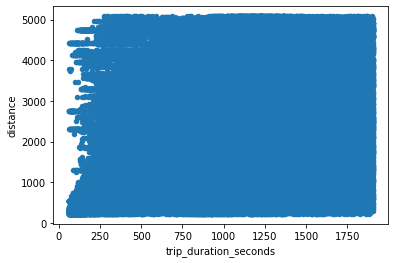

However, because the sample size is extremely large, numerous dots dominated the whole graph. I was still not able to discover any relationship from the graph.

**Thirdly**, I decided to group the data by one of the two variables and analyse in groups.

The variable `trip_duration_seconds` are all integers, while the variable `distance` are floats. I chose to group by data by `trip_duration_seconds` and calculated the mean of `distance`. Thus, I got a dataframe named `dis_mean` with two columns: the column `distance` represents the average distance a rider travels with the `trip_duration_seconds`.

|  | trip_duration_seconds | distance |
| --- | --- | --- |
| 0 | 60 | 380.998968 |
| 1 | 61 | 303.124118 |
| 2 | 62 | 684.669950 |
| 3 | 63 | 297.508107 |
| 4 | 64 | 466.710895 |

**After that**, I draw a scatter plot of the mean `distance` and `trip_duration_seconds`, with the new dataframe `dis_mean`.

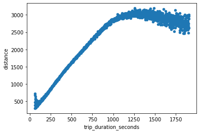

**Finally**, from this graph, it is obvious that the mean `distance` traveled is positively related to the `trip_duration_seconds`. The relationship is linear and extremely strong, when the `trip_duration_seconds` is between 100 to 1000 seconds. But the variance is larger when the `trip_duration_seconds` is shorter than 100 seconds or longer than 1000 seconds.

### conclusions and considerations:

- We have two definitions for trip length: `distance`(the distance of the trip) and `trip_duration_seonds`(the time duration of the trip).
- The `distance`, in average, is positively related to the `trip_duration_seconds`.
- The relationship is linear and strong, especailly with trips between 100 to 1000 seconds:
  - **explanation**: The conclusion is corresponding to our common sense that the farther the trip is, the longer time it takes.
- The correlation is weaker when the `trip_duration_seconds` is less than 100 or more than 1000 seconds:
  - **explanation**:
    - When the `trip_duration_seconds` is less than 100, probably the data is not accurate, because it is weird to travel so far within 2 minutes.
    - When the `trip_duration_secodns` is more than 1000, probably the `trip_duration_seconds` is not sololy determined by the `distance`.
      - Riders could already travel 3000 meters within 1000 seconds, and it is rare to ride farther than 3000 meters by bikeshare.
      - Users who rides more than 1000 meters might have stopped on their way and dealed with other things.
- **limitation**: We drew the conclusion only based on the mean `distance`, rather than individual trips, so it works only in aggregate and individual difference might exist.

## 2. Casual Users v.s. Members

I noticed that there are two types of users of Bikeshare: casual users and members. I would also like to investigate whether there are distinct differences in the length of trips between members vs. casual users.

**To begin with**, I used the `groupby` and `describe` function to see the simple profile of `trip_duration_seconds` and `distance` of two types of users separately.

| user_type | trip_duration_seconds count | trip_duration_seconds mean | trip_duration_seconds std | trip_duration_seconds min | trip_duration_seconds 25% | trip_duration_seconds 50% | trip_duration_seconds 75% | trip_duration_seconds max | distance count | distance mean | distance std | distance min | distance 25% | distance 50% | distance 75% | distance max |
| --- | --- | --- | --- | --- | --- | --- | --- | --- | --- | --- | --- | --- | --- | --- | --- | --- |
| Casual | 320483.0 | 973.762434 | 411.411103 | 60.0 | 649.0 | 945.0 | 1279.0 | 1905.0 | 320483.0 | 2111.128785 | 1071.062703 | 216.824294 | 1279.617089 | 1946.371074 | 2798.940788 | 5079.659527 |
| Member | 1520718.0 | 630.250933 | 321.425057 | 60.0 | 387.0 | 572.0 | 820.0 | 1905.0 | 1520718.0 | 1936.463538 | 1030.654724 | 216.824294 | 1148.266894 | 1737.737598 | 2540.931202 | 5079.659527 |

More adjectively, I also drew a set of boxplots for this data to visualize the difference.

```
Casual         AxesSubplot(0.1,0.15;0.363636x0.75)
Member    AxesSubplot(0.536364,0.15;0.363636x0.75)
dtype: object
```

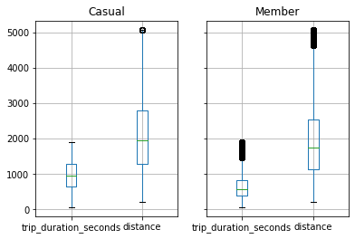

From the table and the graphs, I noticed that with the same min and max, the 25% quantile, 50% quantile, 75% quantile, and mean of both the `trip_duration_seconds` and `distance` of casual users are larger than those of members.

**Further more**, in order to find out the relationship between these two definitions of trip length of both types of users, I also drew a scatter plot to illustrate.

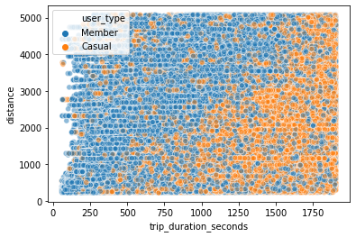

In this graph, the blue dots representing members dominates the upper-left corner, showing that members tends to take "longer" trips defined by `distance`; the orange dots representing casual users dominates the lower-right corner, showing the casual users tends to take "longer" trips defined by `trip_duration_seconds`

However, there are too many dots on the graph, so the observation might not be accurate. Instead, I also plotted `replots` to further demonstrate the relationships.

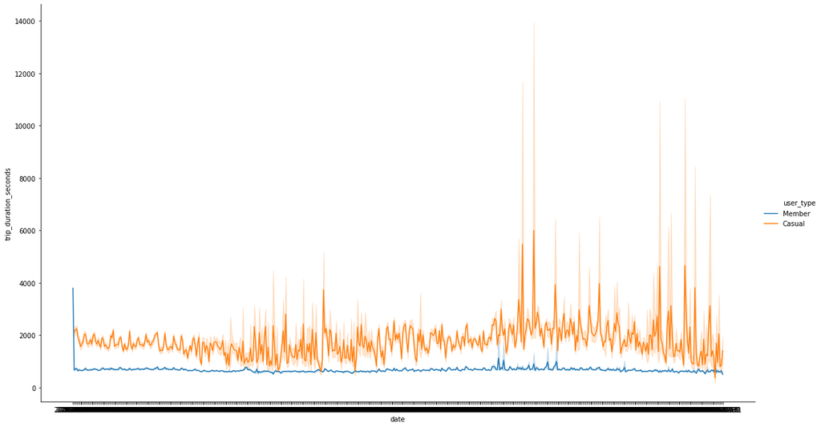

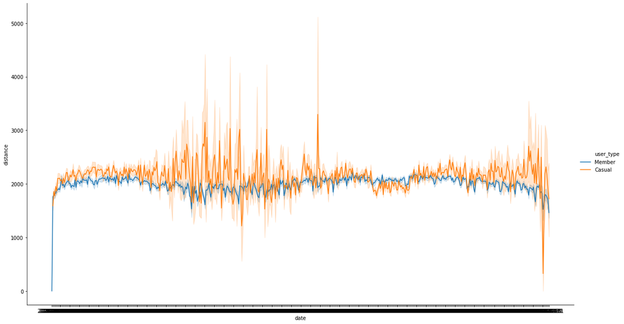

From this graph, I discovered that the trip length defined by `distance` still varies more among casual members than that among members, but the `distance` of trips of casual users is only slightly higher then that of members.

**Next**, to further investigate this relationship, I used the same strategy as investigating the relationship between `trip_duration_seconds` and `distance`.

I grouped the data by `trip_duration_seconds`, calculated the mean of `distance` in each group, and drew a new scatter plot using the grouped data.

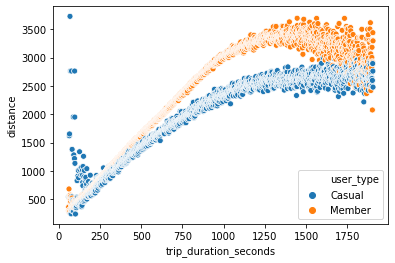

From this graph, it is obvious that with the same `trip_duration_seconds`, members tend to travel further in `distance` than casual users.

## 3. Relationship between Weather and Trip Length.

**First**, I would analyse the relationship between the ridership and the mean temperature.

- **Consider the `distance` and `mean_temp`**

To visualize the relationship, I drew a scatter plot with regression line of the `mean_temp` and `distance` from the `weather_data` dataframe.

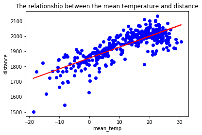

From this graph, we saw that the mean `distance` travelled in a day and the `mean_temp` of that day is positively related, and the relation is strong.

- **Consider the `duration` and `mean_temperature`**

Similarly, I drew a scatter plot with regression line of the `mean_temp` and `duration` from the weather_data dataframe.

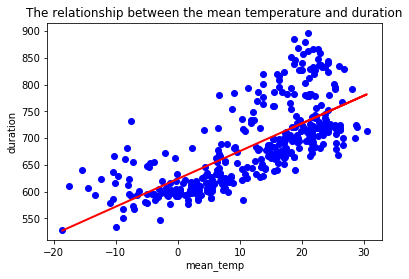

From this graph, we saw that the mean `duration` of trips in a day and the `mean_temp` of that day is positively related. But the relation is weaker than that of `distance` and `mean_temp`.

**Next**, we were also interested in the relationship between the trip length and precipitation.

Instead of regarding precipitation as a numeric variable, I chose to convert it to a qualitative variable `rain` representing whether there is precipitation in a day or not.

Thus, I created a new column named `rain`. Its value is true when the `total_precip` is not zero and false when `total_precip` equals zero.

|  | mean_temp | total_precip | date | duration | distance | rain |
| --- | --- | --- | --- | --- | --- | --- |
| 0 | 18.3 | 5.6 | 2016-07-01 | 755.201842 | 1813.031033 | True |
| 1 | 19.4 | 0.0 | 2016-07-02 | 867.896169 | 1899.371816 | False |
| 2 | 21.0 | 0.0 | 2016-07-03 | 862.735355 | 1879.030543 | False |
| 3 | 21.8 | 0.0 | 2016-07-04 | 723.247626 | 1883.836123 | False |
| 4 | 26.1 | 0.0 | 2016-07-05 | 714.957033 | 1905.608854 | False |

Then, I used the `describe()` function to get a simple profile of the mean `duration` and `distance` when it has precipitation or not during the day respectively.

| rain | duration count | duration mean | duration std | duration min | duration 25% | duration 50% | duration 75% | duration max | distance count | distance mean | distance std | distance min | distance 25% | distance 50% | distance 75% | distance max |
| --- | --- | --- | --- | --- | --- | --- | --- | --- | --- | --- | --- | --- | --- | --- | --- | --- |
| False | 227.0 | 699.111793 | 78.344167 | 528.588068 | 637.965081 | 694.721543 | 736.164144 | 884.729418 | 227.0 | 1958.285918 | 93.934802 | 1503.407902 | 1909.296917 | 1987.358957 | 2016.744505 | 2133.511386 |
| True | 149.0 | 664.545126 | 70.401035 | 547.986938 | 606.116468 | 646.533937 | 707.066646 | 896.712727 | 149.0 | 1915.392441 | 89.483859 | 1545.519953 | 1861.317034 | 1920.515256 | 1988.454408 | 2084.190071 |

From the table, it is easy to discover that the mean, 25% quantile, 50% quantile, and 75% quantile of both the average `duration` and the `distance` of the trips in a day are larger when there is no precipitation in that day.

I also drew two sets of boxplots to visualize the above results.

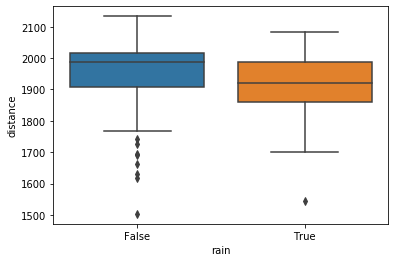

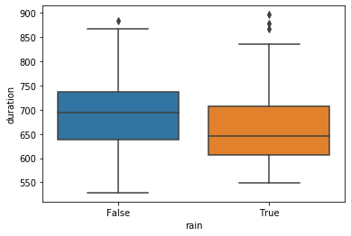

Also, I drew two histgrams of mean `duration` of trips in a day to further support the result.

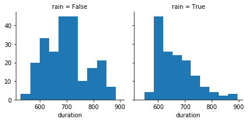

From the histgrams, we saw that the distribution of `duration` when there is no precipitation is bimodel, with a higher peak at 700 seconds and a lower peak around 800 seconds. However, the distribution of `duration` when there is precipitation is unimodel, with the mode at 600 seconds, and the longer the duration, the smaller counts it has.

However, it seemed that there is not obvious patterns in the graph and the correlation between precipitaion and ridership seemed to be low.

### Conclusion and consideration.

- The trip length is positively related to the mean temperature of the day in both definition of `distance` and `duration`.
  - The higher the temperature, the longer the trips are.
    - **Explanation**: Considering the weather characteristics in Toronto, it is sometimes very cold, but seldom gets extremly hot. It is inconvenient to ride bikes when it is cold, but the higher temperature would not lead to any inconvenience.
  - The corelation between the `distance` and `mean_temp` is relatively stronger than that between `duration` and `mean_temp`
    - **Explanation**: The distance to travel depends only on the rider, but the duration of trips to travel the same distance can also be affected by the weather condition. So riders could choose to take trips shorter in distance when the temperature is lower, but it might take longer times to travel for the same distance in winter when the temperature is lower.
- The average length of trips is shorter when there is precipitation in a day, and it is longer when there is no precipitation.
  - **Explanation**: Probably because, when there is precipitaion, either rain or snow, it is not convenient to rider.
  - **Limitation**: When the data is divided into two groups: precipitation or no precipitation, the sample size of each group is not large enough, so the result might not be accurate.

| rain | duration | distance |
| --- | --- | --- |
| False | 227 | 227 |
| True | 149 | 149 |

- **Limitation**: These conclusions are only based on the mean `distance` and `duration` of all trips in each day, so it can only gives us a relationship in general. It might not be appliable to individuals as individual difference might exist.
- **Possible improvement**: The data only provides the total precipitation and mean temperature at specific weather station location. However, the temperature can vary a lot and the rainfall also might not be consistent throughout the entire day and across all Bike Share stations locations. Therefore, the conclusion based on the weather of the entire day might not be concrete and precise. Since the ridership varies depending on hour and specific stations, the weather data on an hourly level and from multiple weather stations are necessary for further investigations.

## Summary

While the Bikeshare Ridership data provided on the Open Datta is fairly simple, containing only basic information of each trips, I merged it with other public resources and finally got some sights into the characteristics of the data:

1. The duration and distance of trip are positively related. The correlation is strong for trips taking between 100 and 1000 seconds, but weaker otherwise.
   - This is corresponding to our common senses: the farther the trip, the longer time it takes.
   - Users might have stopped during their trips longer than 1000 seconds, so the duration is not sololy determined by the distance.
2. Casual users tend to take longer trips, especially longer in duration.
   - Probably because it is more economical for casual users to take longer trips.
   - Casual users might spend more time to travel the same distance considering their unfamiliarity.
3. Users tend to take longer trips, espcially in distance, when it is warmer and there is no precipitation in during the day.
   - Considering the weather characteristics of the city, Toronto, it is more convenient to ride bikes when it is warmer and with no precitipation.
   - The duration of trips to travel the same distance can also be affected by the weather condition.

There are also some limitations and possible improvements of the analysis and they are discussed in the conclusion and considerations under each specific topic.

This analysis gives us a glimpse into the bikeshare ridership in Toronto. We understood some traits of the ridership. I hope this analysis could help find out a better way providing the bikeshare service.